# Modeling and prediction for movies, Coursera Duke University

Masoud Asgharian Rostami

7/10/2019

## Setup

### Load packages

```r
library(corrplot)
library(dplyr)
library(ggplot2)
library(shiny)
library(statsr)
library(tidyverse)
library(knitr)
library(rmarkdown)
```

### Load data

```r
load("movies.Rdata")
```

## Part 1: Data

The Movies data set include 651 cases (randomly sampled) and 32 variables.These movies are produced before 2016. This is a observational study not experiment (treatment and control) because all the variables are found in the websites or asked from people.These data are randomly colleected but not randomly assigned therfore association and correlation between the variables and movies interest can be idntified, however causation relationship can not be achieved. In addition, because it is randomly selected it can be generlised to population.

## Part 2: Research question

What are the most important factors that impact the audience_score?

## Part 3: Exploratory data analysis

```r
dim(movies)
```

```
## [1] 651  32
```

```r
str(movies)
```

```
## Classes 'tbl_df', 'tbl' and 'data.frame':    651 obs. of  32 variables:
##  $ title           : chr  "Filly Brown" "The Dish" "Waiting for Guffman" "The Age of Innocence" ...
##  $ title_type      : Factor w/ 3 levels "Documentary",..: 2 2 2 2 2 1 2 2 1 2 ...
##  $ genre           : Factor w/ 11 levels "Action & Adventure",..: 6 6 4 6 7 5 6 6 5 6 ...
##  $ runtime         : num  80 101 84 139 90 78 142 93 88 119 ...
##  $ mpaa_rating     : Factor w/ 6 levels "G","NC-17","PG",..: 5 4 5 3 5 6 4 5 6 6 ...
##  $ studio          : Factor w/ 211 levels "20th Century Fox",..: 91 202 167 34 13 163 147 118 88 84 ...
##  $ thtr_rel_year   : num  2013 2001 1996 1993 2004 ...
##  $ thtr_rel_month  : num  4 3 8 10 9 1 1 11 9 3 ...
##  $ thtr_rel_day    : num  19 14 21 1 10 15 1 8 7 2 ...
##  $ dvd_rel_year    : num  2013 2001 2001 2001 2005 ...
##  $ dvd_rel_month   : num  7 8 8 11 4 4 2 3 1 8 ...
##  $ dvd_rel_day     : num  30 28 21 6 19 20 18 2 21 14 ...
##  $ imdb_rating     : num  5.5 7.3 7.6 7.2 5.1 7.8 7.2 5.5 7.5 6.6 ...
##  $ imdb_num_votes  : int  899 12285 22381 35096 2386 333 5016 2272 880 12496 ...
```

[output cut: 18 more lines]

```r
names(movies)
```

```
##  [1] "title"            "title_type"       "genre"
##  [4] "runtime"          "mpaa_rating"      "studio"
##  [7] "thtr_rel_year"    "thtr_rel_month"   "thtr_rel_day"
## [10] "dvd_rel_year"     "dvd_rel_month"    "dvd_rel_day"
## [13] "imdb_rating"      "imdb_num_votes"   "critics_rating"
## [16] "critics_score"    "audience_rating"  "audience_score"
## [19] "best_pic_nom"     "best_pic_win"     "best_actor_win"
## [22] "best_actress_win" "best_dir_win"     "top200_box"
## [25] "director"         "actor1"           "actor2"
## [28] "actor3"           "actor4"           "actor5"
## [31] "imdb_url"         "rt_url"
```

```r
summary(movies)
```

```
##     title                  title_type                 genre
##  Length:651         Documentary : 55   Drama             :305
##  Class :character   Feature Film:591   Comedy            : 87
##  Mode  :character   TV Movie    :  5   Action & Adventure: 65
##                                        Mystery & Suspense: 59
##                                        Documentary       : 52
##                                        Horror            : 23
##                                        (Other)           : 60
##     runtime       mpaa_rating                               studio
##  Min.   : 39.0   G      : 19   Paramount Pictures              : 37
##  1st Qu.: 92.0   NC-17  :  2   Warner Bros. Pictures           : 30
##  Median :103.0   PG     :118   Sony Pictures Home Entertainment: 27
##  Mean   :105.8   PG-13  :133   Universal Pictures              : 23
##  3rd Qu.:115.8   R      :329   Warner Home Video               : 19
##  Max.   :267.0   Unrated: 50   (Other)                         :507
##  NA's   :1                     NA's                            :  8
##  thtr_rel_year  thtr_rel_month   thtr_rel_day    dvd_rel_year
##  Min.   :1970   Min.   : 1.00   Min.   : 1.00   Min.   :1991
##  1st Qu.:1990   1st Qu.: 4.00   1st Qu.: 7.00   1st Qu.:2001
##  Median :2000   Median : 7.00   Median :15.00   Median :2004
##  Mean   :1998   Mean   : 6.74   Mean   :14.42   Mean   :2004
##  3rd Qu.:2007   3rd Qu.:10.00   3rd Qu.:21.00   3rd Qu.:2008
##  Max.   :2014   Max.   :12.00   Max.   :31.00   Max.   :2015
##                                                 NA's   :8
##  dvd_rel_month     dvd_rel_day     imdb_rating    imdb_num_votes
##  Min.   : 1.000   Min.   : 1.00   Min.   :1.900   Min.   :   180
##  1st Qu.: 3.000   1st Qu.: 7.00   1st Qu.:5.900   1st Qu.:  4546
##  Median : 6.000   Median :15.00   Median :6.600   Median : 15116
##  Mean   : 6.333   Mean   :15.01   Mean   :6.493   Mean   : 57533
##  3rd Qu.: 9.000   3rd Qu.:23.00   3rd Qu.:7.300   3rd Qu.: 58301
##  Max.   :12.000   Max.   :31.00   Max.   :9.000   Max.   :893008
##  NA's   :8        NA's   :8
##          critics_rating critics_score    audience_rating audience_score
##  Certified Fresh:135    Min.   :  1.00   Spilled:275     Min.   :11.00
##  Fresh          :209    1st Qu.: 33.00   Upright:376     1st Qu.:46.00
##  Rotten         :307    Median : 61.00                   Median :65.00
##                         Mean   : 57.69                   Mean   :62.36
##                         3rd Qu.: 83.00                   3rd Qu.:80.00
##                         Max.   :100.00                   Max.   :97.00
##
```

[output cut: 17 more lines]

```
##  Length:651         Length:651         Length:651
##  Class :character   Class :character   Class :character
##  Mode  :character   Mode  :character   Mode  :character
##
##
##
##
##    imdb_url            rt_url
##  Length:651         Length:651
##  Class :character   Class :character
##  Mode  :character   Mode  :character
##
##
##
##
```

#### Remove missing values and select important variables

```r
movies2 <- na.omit(movies) %>%
  select (genre, runtime,studio,thtr_rel_month,imdb_rating, imdb_num_votes, critics_score,
          critics_rating, audience_rating, audience_score, best_pic_nom, best_pic_win,best_actor_win,best_actress_win,
          top200_box,director, actor1)

head(movies2)
```

```
## # A tibble: 6 x 17
##   genre runtime studio thtr_rel_month imdb_rating imdb_num_votes
##   <fct>   <dbl> <fct>           <dbl>       <dbl>          <int>
## 1 Drama      80 Indom~              4         5.5            899
## 2 Drama     101 Warne~              3         7.3          12285
## 3 Come~      84 Sony ~              8         7.6          22381
## 4 Drama     139 Colum~             10         7.2          35096
## 5 Horr~      90 Ancho~              9         5.1           2386
## 6 Drama     142 Param~              1         7.2           5016
## # ... with 11 more variables: critics_score <dbl>, critics_rating <fct>,
## #   audience_rating <fct>, audience_score <dbl>, best_pic_nom <fct>,
## #   best_pic_win <fct>, best_actor_win <fct>, best_actress_win <fct>,
## #   top200_box <fct>, director <chr>, actor1 <chr>
```

```r
dim(movies2)
```

```
## [1] 619  17
```

#### Plot (Audience scores by genre)

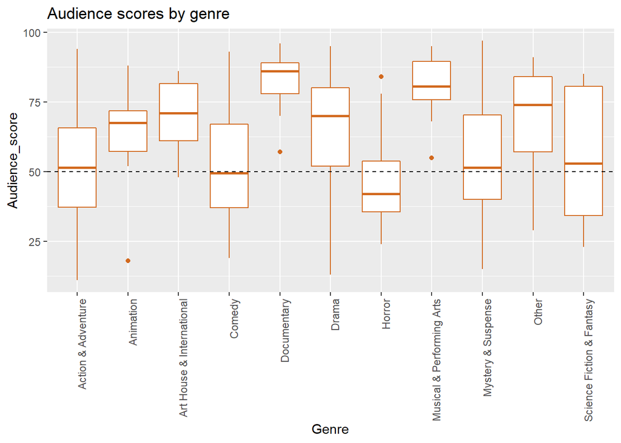

```r
ggplot(data=movies2, aes(x=genre, y=audience_score))+geom_boxplot(col="chocolate")+theme(axis.text.x=element_text(angle = 90, hjust = 1))+
  ggtitle("Audience scores by genre")+xlab(" Genre ") + ylab("Audience_score")+geom_hline(yintercept=50, lty="dashed")
```

It seems Musical&Performing Arts and Documentary have the highest Audience score.

#### Plot (Audience scores vs Runtime of movie (in minutes))

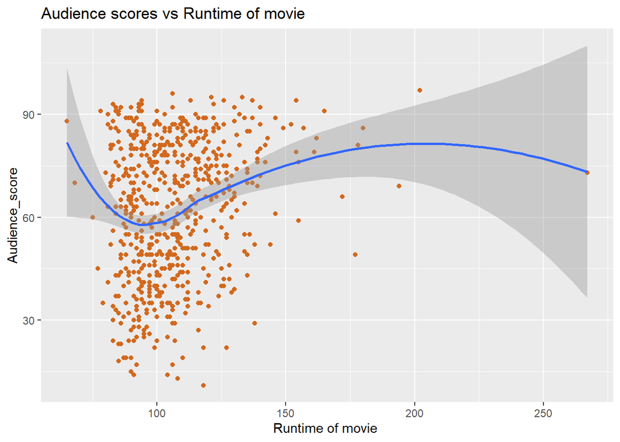

```r
ggplot(data=movies2, aes(x=  runtime, y=audience_score))+geom_point(col="chocolate")+
  ggtitle("Audience scores vs Runtime of movie")+xlab("Runtime of movie ") + ylab("Audience_score")+geom_smooth()
```

It seems there is relationship between Audience scores vs Runtime of movie.

#### Plot (Audience scores vs IMDB rating by genre)

[figure not shown]

```r
ggplot(data=movies2, aes(x=imdb_rating, y=audience_score))+geom_boxplot(col="chocolate")+ggtitle("Audience scores vs IMDB rating by genre")+xlab(" IMDB rating") + ylab("Audience_score")+geom_hline(yintercept=50, lty="dashed")+
  facet_wrap(~genre)
```

It seems Musical&Performing Arts and Documentary have the highest Audience score and lowest range in box plot.

#### Plot(Audience scores vs IMDB number of voters)

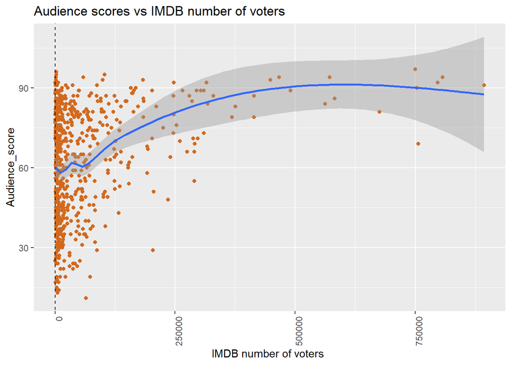

```r
ggplot(data=movies2, aes(x= imdb_num_votes, y=audience_score))+geom_point(col="chocolate")+theme(axis.text.x=element_text(angle = 90, hjust = 1))+
  ggtitle("Audience scores vs IMDB number of voters")+xlab("IMDB number of voters ") + ylab("Audience_score")+geom_abline(lty="dashed")+geom_smooth()
```

It seems Audience scores vs IMDB number of voters have relatively positive correlation.

#### Plot (Audience scores by Critics rating)

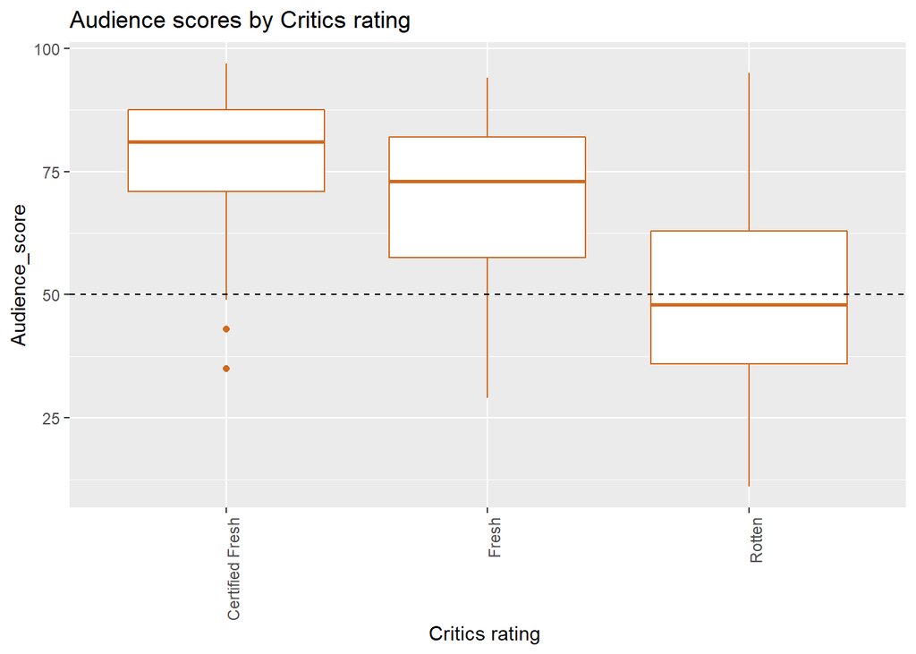

```r
ggplot(data=movies2, aes(x=critics_rating, y=audience_score))+geom_boxplot(col="chocolate")+theme(axis.text.x=element_text(angle = 90, hjust = 1))+
  ggtitle("Audience scores by Critics rating")+xlab("Critics rating ") + ylab("Audience_score")+geom_hline(yintercept=50, lty="dashed")
```

It shows critics rating with Certified Freash has the highest Audience scores.

#### Plot (Audience scores by nominated for a best picture Oscar)

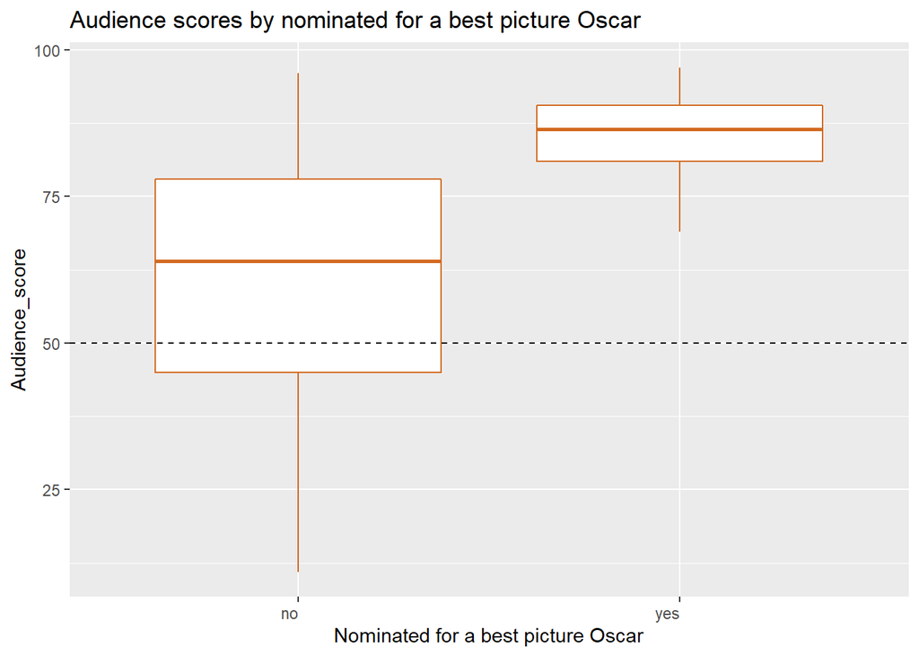

```r
ggplot(data=movies2, aes(x=best_pic_nom, y=audience_score))+geom_boxplot(col="chocolate")+theme(axis.text.x=element_text(angle = 0, hjust = 1))+ggtitle("Audience scores by nominated for a best picture Oscar")+xlab("Nominated for a best picture Oscar") + ylab("Audience_score")+geom_hline(yintercept=50, lty="dashed")
```

THe movies that by nominated for a best picture Oscar have the highest scores.

#### Plot (Audience scores by movie won a best picture Oscar)

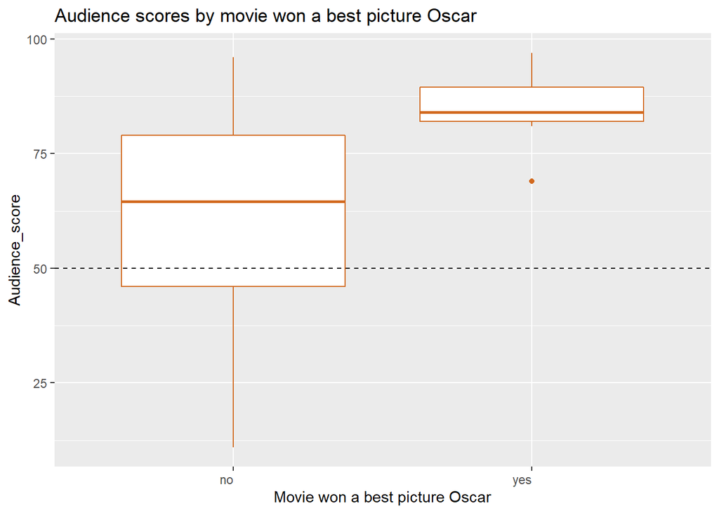

```r
ggplot(data=movies2, aes(x=best_pic_win, y=audience_score))+geom_boxplot(col="chocolate")+theme(axis.text.x=element_text(angle = 0, hjust = 1))+
  ggtitle("Audience scores by movie won a best picture Oscar ")+xlab("Movie won a best picture Oscar") + ylab("Audience_score")+geom_hline(yintercept=50, lty="dashed")
```

THe movies that won best picture of Oscar have the highest scores.

#### Plot(Audience scores by actors in the movie ever won an Oscar)

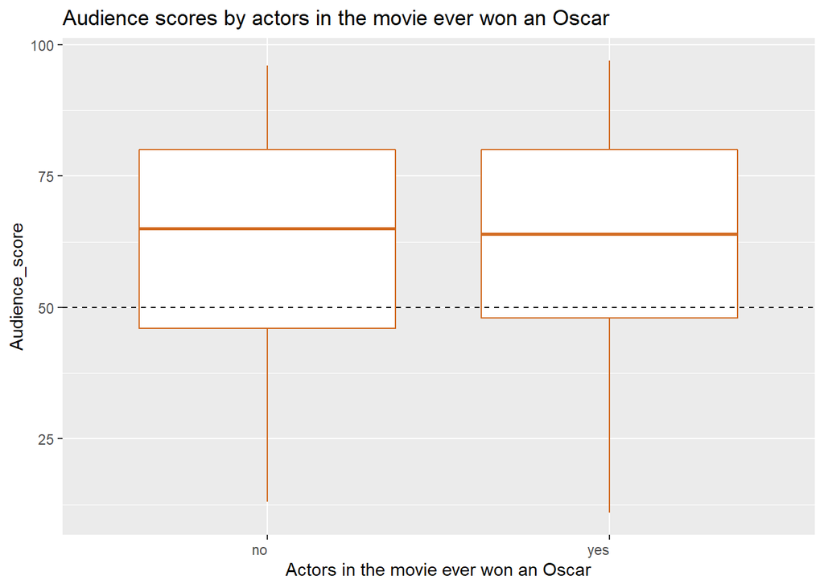

```r
ggplot(data=movies2, aes(x=best_actor_win, y=audience_score))+geom_boxplot(col="chocolate")+theme(axis.text.x=element_text(angle =0, hjust = 1))+
  ggtitle("Audience scores by actors in the movie ever won an Oscar")+xlab("Actors in the movie ever won an Oscar") + ylab("Audience_score")+geom_hline(yintercept=50, lty="dashed")
```

This boxplot show the audience scores between actors in the movie ever won an Oscar and not won the oscar is similar.

#### Plot (Audience scores by actress in the movie ever won an Oscar)

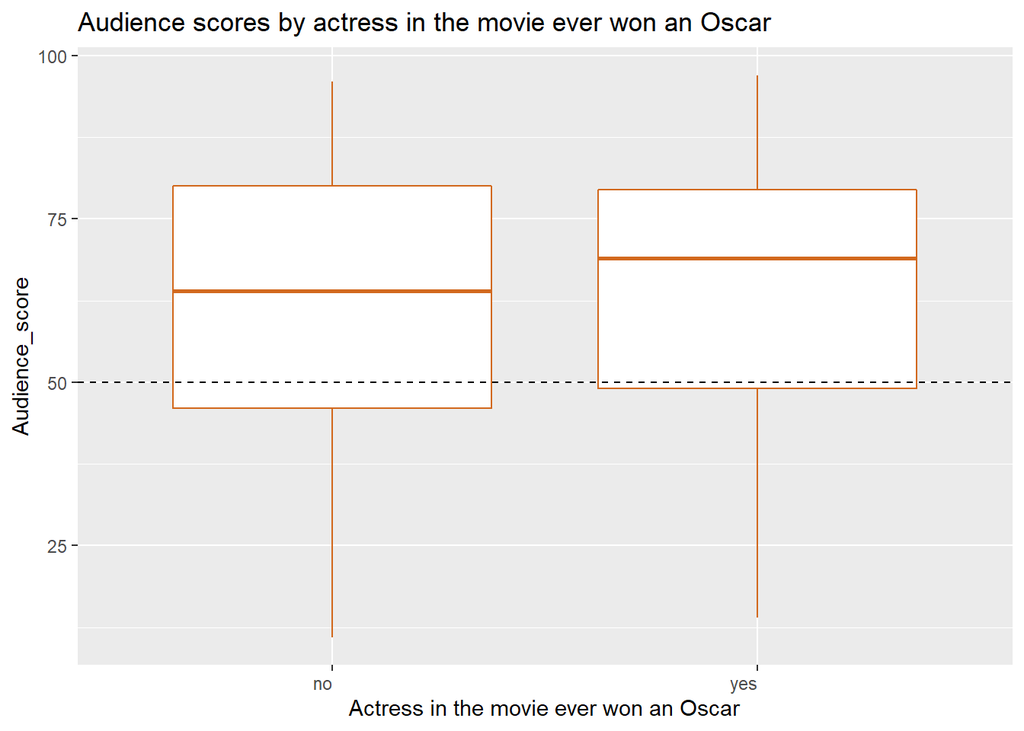

```r
ggplot(data=movies2, aes(x=best_actress_win, y=audience_score))+geom_boxplot(col="chocolate")+theme(axis.text.x=element_text(angle = 0, hjust = 1))+
  ggtitle("Audience scores by actress in the movie ever won an Oscar")+xlab("Actress in the movie ever won an Oscar") + ylab("Audience_score")+geom_hline(yintercept=50, lty="dashed")
```

This boxplot show the audience scores between actress in the movie ever won an Oscar and not won the oscar is similar.

#### Plot (Audience scores by Whether or not the movie is in the Top 200 Box Office)

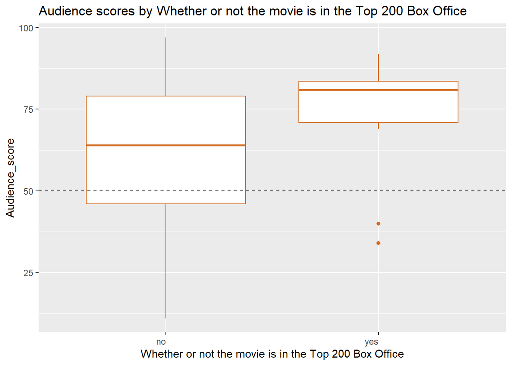

```r
ggplot(data=movies2, aes(x= top200_box, y=audience_score))+geom_boxplot(col="chocolate")+theme(axis.text.x=element_text(angle = 0, hjust = 1))+
  ggtitle("Audience scores by Whether or not the movie is in the Top 200 Box Office")+xlab("Whether or not the movie is in the Top 200 Box Office") + ylab("Audience_score")+geom_hline(yintercept=50, lty="dashed")
```

It seems movies in Top 200 Box Office have higher Audience scores.

## Part 4: Modeling

In this modeling project, 12 variables for the full model selected based on EPA. Backward model by using adjust R2 is going to apply to find the simplest and best model with less variables.

#### 1) This is a first full model

```r
model_full1<-lm(audience_score~genre+thtr_rel_month+imdb_rating+imdb_num_votes+ critics_score+ critics_rating+ audience_rating+ best_pic_nom+ best_pic_win+ top200_box+best_actor_win+best_actress_win, data=movies2)

summary(model_full1)
```

```
##
## Call:
## lm(formula = audience_score ~ genre + thtr_rel_month + imdb_rating +
##     imdb_num_votes + critics_score + critics_rating + audience_rating +
##     best_pic_nom + best_pic_win + top200_box + best_actor_win +
##     best_actress_win, data = movies2)
##
## Residuals:
##      Min       1Q   Median       3Q      Max
## -21.5006  -4.5859   0.5476   4.1787  23.9458
##
## Coefficients:
##                                  Estimate Std. Error t value Pr(>|t|)
## (Intercept)                    -8.625e+00  2.957e+00  -2.917  0.00367 **
## genreAnimation                  5.496e+00  2.613e+00   2.103  0.03586 *
## genreArt House & International -1.790e+00  2.226e+00  -0.804  0.42163
## genreComedy                     1.741e+00  1.164e+00   1.496  0.13523
## genreDocumentary                1.524e+00  1.558e+00   0.978  0.32854
## genreDrama                     -6.583e-01  1.016e+00  -0.648  0.51723
## genreHorror                    -1.459e+00  1.723e+00  -0.847  0.39758
## genreMusical & Performing Arts  3.050e+00  2.239e+00   1.362  0.17358
## genreMystery & Suspense        -3.348e+00  1.310e+00  -2.557  0.01081 *
## genreOther                     -2.417e-02  2.019e+00  -0.012  0.99046
## genreScience Fiction & Fantasy  7.810e-02  2.597e+00   0.030  0.97601
## thtr_rel_month                 -1.542e-01  8.074e-02  -1.909  0.05671 .
## imdb_rating                     9.254e+00  4.978e-01  18.590  < 2e-16 ***
## imdb_num_votes                  2.300e-06  3.146e-06   0.731  0.46497
## critics_score                   1.172e-02  2.526e-02   0.464  0.64289
## critics_ratingFresh             1.179e-01  8.873e-01   0.133  0.89431
## critics_ratingRotten           -6.012e-01  1.418e+00  -0.424  0.67174
## audience_ratingUpright          2.018e+01  8.068e-01  25.014  < 2e-16 ***
## best_pic_nomyes                 4.047e+00  1.819e+00   2.225  0.02646 *
## best_pic_winyes                -2.525e+00  3.054e+00  -0.827  0.40864
## top200_boxyes                  -1.020e-01  1.912e+00  -0.053  0.95747
## best_actor_winyes              -3.980e-03  8.166e-01  -0.005  0.99611
## best_actress_winyes            -1.402e+00  9.107e-01  -1.540  0.12419
## ---
## Signif. codes:  0 '***' 0.001 '**' 0.01 '*' 0.05 '.' 0.1 ' ' 1
##
## Residual standard error: 6.872 on 596 degrees of freedom
## Multiple R-squared:  0.8881, Adjusted R-squared:  0.884
## F-statistic: 215.1 on 22 and 596 DF,  p-value: < 2.2e-16
```

Linear model shows an an adjusted R2 value of 0.8839. This show ~88% of variability explain with these variables.

#### 2) Remove veriable best_actress_win

```r
model_2<-lm(audience_score~genre+thtr_rel_month+imdb_rating+imdb_num_votes+ critics_score+
              critics_rating+ audience_rating+ best_pic_nom+ best_pic_win+ top200_box+best_actor_win, data=movies2)

summary(model_2)
```

```
##
## Call:
## lm(formula = audience_score ~ genre + thtr_rel_month + imdb_rating +
##     imdb_num_votes + critics_score + critics_rating + audience_rating +
##     best_pic_nom + best_pic_win + top200_box + best_actor_win,
##     data = movies2)
##
## Residuals:
##      Min       1Q   Median       3Q      Max
## -21.2764  -4.5207   0.5906   4.2620  24.1182
##
## Coefficients:
##                                  Estimate Std. Error t value Pr(>|t|)
## (Intercept)                    -8.466e+00  2.959e+00  -2.861  0.00437 **
## genreAnimation                  5.296e+00  2.613e+00   2.027  0.04313 *
## genreArt House & International -1.950e+00  2.226e+00  -0.876  0.38147
## genreComedy                     1.581e+00  1.160e+00   1.362  0.17367
## genreDocumentary                1.457e+00  1.560e+00   0.934  0.35062
## genreDrama                     -8.673e-01  1.008e+00  -0.861  0.38985
## genreHorror                    -1.482e+00  1.725e+00  -0.859  0.39056
## genreMusical & Performing Arts  3.029e+00  2.241e+00   1.351  0.17713
## genreMystery & Suspense        -3.581e+00  1.302e+00  -2.750  0.00614 **
## genreOther                     -1.766e-01  2.019e+00  -0.087  0.93035
## genreScience Fiction & Fantasy  6.499e-02  2.600e+00   0.025  0.98006
## thtr_rel_month                 -1.548e-01  8.083e-02  -1.915  0.05593 .
## imdb_rating                     9.239e+00  4.983e-01  18.542  < 2e-16 ***
## imdb_num_votes                  2.262e-06  3.149e-06   0.718  0.47279
## critics_score                   1.072e-02  2.528e-02   0.424  0.67178
## critics_ratingFresh             1.781e-01  8.874e-01   0.201  0.84098
## critics_ratingRotten           -6.316e-01  1.420e+00  -0.445  0.65655
## audience_ratingUpright          2.023e+01  8.071e-01  25.067  < 2e-16 ***
## best_pic_nomyes                 3.748e+00  1.810e+00   2.070  0.03884 *
## best_pic_winyes                -2.790e+00  3.053e+00  -0.914  0.36115
## top200_boxyes                  -2.764e-01  1.911e+00  -0.145  0.88504
## best_actor_winyes              -1.045e-01  8.149e-01  -0.128  0.89799
## ---
## Signif. codes:  0 '***' 0.001 '**' 0.01 '*' 0.05 '.' 0.1 ' ' 1
##
## Residual standard error: 6.88 on 597 degrees of freedom
## Multiple R-squared:  0.8877, Adjusted R-squared:  0.8837
## F-statistic: 224.7 on 21 and 597 DF,  p-value: < 2.2e-16
```

Adjusted R2 for model 1 is 0.8837

#### 3) Remove veriable best_pic_nom

```r
model_3<-lm(audience_score~genre+thtr_rel_month+imdb_rating+imdb_num_votes+ critics_score+
              critics_rating+ audience_rating+ best_pic_win+ top200_box+best_actor_win, data=movies2)

summary(model_3)
```

```
##
## Call:
## lm(formula = audience_score ~ genre + thtr_rel_month + imdb_rating +
##     imdb_num_votes + critics_score + critics_rating + audience_rating +
##     best_pic_win + top200_box + best_actor_win, data = movies2)
##
## Residuals:
##      Min       1Q   Median       3Q      Max
## -21.2882  -4.5822   0.5887   4.1628  24.1775
##
## Coefficients:
##                                  Estimate Std. Error t value Pr(>|t|)
## (Intercept)                    -8.821e+00  2.962e+00  -2.978  0.00302 **
## genreAnimation                  5.255e+00  2.620e+00   2.005  0.04536 *
## genreArt House & International -1.946e+00  2.232e+00  -0.872  0.38375
## genreComedy                     1.624e+00  1.163e+00   1.396  0.16334
## genreDocumentary                1.390e+00  1.564e+00   0.889  0.37425
## genreDrama                     -7.654e-01  1.009e+00  -0.758  0.44865
## genreHorror                    -1.410e+00  1.729e+00  -0.815  0.41524
## genreMusical & Performing Arts  2.938e+00  2.247e+00   1.307  0.19158
## genreMystery & Suspense        -3.541e+00  1.306e+00  -2.712  0.00688 **
## genreOther                      2.311e-01  2.015e+00   0.115  0.90875
## genreScience Fiction & Fantasy  8.459e-02  2.607e+00   0.032  0.97412
## thtr_rel_month                 -1.315e-01  8.027e-02  -1.639  0.10179
## imdb_rating                     9.264e+00  4.995e-01  18.548  < 2e-16 ***
## imdb_num_votes                  2.919e-06  3.142e-06   0.929  0.35324
## critics_score                   1.220e-02  2.534e-02   0.481  0.63052
## critics_ratingFresh             2.395e-02  8.867e-01   0.027  0.97846
## critics_ratingRotten           -7.354e-01  1.423e+00  -0.517  0.60537
## audience_ratingUpright          2.026e+01  8.092e-01  25.038  < 2e-16 ***
## best_pic_winyes                -1.870e-01  2.789e+00  -0.067  0.94656
## top200_boxyes                  -3.844e-01  1.916e+00  -0.201  0.84103
## best_actor_winyes               1.195e-01  8.099e-01   0.148  0.88270
## ---
## Signif. codes:  0 '***' 0.001 '**' 0.01 '*' 0.05 '.' 0.1 ' ' 1
##
## Residual standard error: 6.899 on 598 degrees of freedom
## Multiple R-squared:  0.8869, Adjusted R-squared:  0.8831
## F-statistic: 234.4 on 20 and 598 DF,  p-value: < 2.2e-16
```

Adjusted R2 for model 2 is 0.8831

#### 4) Remove veriable best_pic_win

```r
model_4<-lm(audience_score~genre+thtr_rel_month+imdb_rating+imdb_num_votes+ critics_score+
              critics_rating+ audience_rating+top200_box+best_actor_win, data=movies2)

summary(model_4)
```

```
##
## Call:
## lm(formula = audience_score ~ genre + thtr_rel_month + imdb_rating +
##     imdb_num_votes + critics_score + critics_rating + audience_rating +
##     top200_box + best_actor_win, data = movies2)
##
## Residuals:
##      Min       1Q   Median       3Q      Max
## -21.2891  -4.5822   0.5891   4.1644  24.1793
##
## Coefficients:
##                                  Estimate Std. Error t value Pr(>|t|)
## (Intercept)                    -8.818e+00  2.959e+00  -2.980  0.00300 **
## genreAnimation                  5.254e+00  2.618e+00   2.007  0.04519 *
## genreArt House & International -1.950e+00  2.230e+00  -0.874  0.38228
## genreComedy                     1.620e+00  1.161e+00   1.395  0.16347
## genreDocumentary                1.388e+00  1.562e+00   0.889  0.37463
## genreDrama                     -7.688e-01  1.007e+00  -0.763  0.44564
## genreHorror                    -1.412e+00  1.727e+00  -0.818  0.41385
## genreMusical & Performing Arts  2.936e+00  2.245e+00   1.308  0.19144
## genreMystery & Suspense        -3.544e+00  1.304e+00  -2.718  0.00675 **
## genreOther                      2.340e-01  2.013e+00   0.116  0.90751
## genreScience Fiction & Fantasy  8.552e-02  2.605e+00   0.033  0.97382
## thtr_rel_month                 -1.317e-01  8.017e-02  -1.642  0.10105
## imdb_rating                     9.265e+00  4.990e-01  18.566  < 2e-16 ***
## imdb_num_votes                  2.867e-06  3.044e-06   0.942  0.34660
## critics_score                   1.212e-02  2.530e-02   0.479  0.63193
## critics_ratingFresh             2.758e-02  8.844e-01   0.031  0.97513
## critics_ratingRotten           -7.340e-01  1.421e+00  -0.516  0.60572
## audience_ratingUpright          2.026e+01  8.084e-01  25.063  < 2e-16 ***
## top200_boxyes                  -3.830e-01  1.914e+00  -0.200  0.84144
## best_actor_winyes               1.189e-01  8.092e-01   0.147  0.88323
## ---
## Signif. codes:  0 '***' 0.001 '**' 0.01 '*' 0.05 '.' 0.1 ' ' 1
##
## Residual standard error: 6.893 on 599 degrees of freedom
## Multiple R-squared:  0.8869, Adjusted R-squared:  0.8833
## F-statistic: 247.2 on 19 and 599 DF,  p-value: < 2.2e-16
```

Adjusted R2 for model 2 is 0.8833

#### 5) Remove veriable imdb_num_votes

```r
model_5<-lm(audience_score~genre+thtr_rel_month+imdb_rating+ critics_score+
              critics_rating+ audience_rating+top200_box+best_actor_win, data=movies2)

summary(model_5)
```

```
##
## Call:
## lm(formula = audience_score ~ genre + thtr_rel_month + imdb_rating +
##     critics_score + critics_rating + audience_rating + top200_box +
##     best_actor_win, data = movies2)
##
## Residuals:
##      Min       1Q   Median       3Q      Max
## -21.3595  -4.5779   0.5866   4.1864  24.5422
##
## Coefficients:
##                                 Estimate Std. Error t value Pr(>|t|)
## (Intercept)                    -9.065699   2.947004  -3.076  0.00219 **
## genreAnimation                  5.199838   2.617002   1.987  0.04738 *
## genreArt House & International -2.248562   2.206787  -1.019  0.30865
## genreComedy                     1.571390   1.159630   1.355  0.17590
## genreDocumentary                1.028485   1.514349   0.679  0.49730
## genreDrama                     -0.874412   1.000997  -0.874  0.38272
## genreHorror                    -1.494034   1.724939  -0.866  0.38676
## genreMusical & Performing Arts  2.659453   2.225609   1.195  0.23259
## genreMystery & Suspense        -3.547540   1.303652  -2.721  0.00669 **
## genreOther                      0.293963   2.011842   0.146  0.88388
## genreScience Fiction & Fantasy  0.093379   2.604276   0.036  0.97141
## thtr_rel_month                 -0.127522   0.080045  -1.593  0.11166
## imdb_rating                     9.410213   0.474569  19.829  < 2e-16 ***
## critics_score                   0.008485   0.024999   0.339  0.73443
## critics_ratingFresh            -0.265491   0.827739  -0.321  0.74852
## critics_ratingRotten           -1.069684   1.375718  -0.778  0.43714
## audience_ratingUpright         20.249113   0.808227  25.054  < 2e-16 ***
## top200_boxyes                  -0.005820   1.871327  -0.003  0.99752
## best_actor_winyes               0.135131   0.808903   0.167  0.86738
## ---
## Signif. codes:  0 '***' 0.001 '**' 0.01 '*' 0.05 '.' 0.1 ' ' 1
##
## Residual standard error: 6.893 on 600 degrees of freedom
## Multiple R-squared:  0.8867, Adjusted R-squared:  0.8833
## F-statistic: 260.9 on 18 and 600 DF,  p-value: < 2.2e-16
```

Adjusted R2 for model 2 is 0.8833

#### 6) Remove veriable thtr_rel_month

```r
model_6<-lm(audience_score~genre+imdb_rating+ critics_score+
              critics_rating+ audience_rating+top200_box+best_actor_win, data=movies2)
summary(model_6)
```

```
##
## Call:
## lm(formula = audience_score ~ genre + imdb_rating + critics_score +
##     critics_rating + audience_rating + top200_box + best_actor_win,
##     data = movies2)
##
## Residuals:
##      Min       1Q   Median       3Q      Max
## -21.3411  -4.6671   0.4649   4.3570  24.4500
##
## Coefficients:
##                                 Estimate Std. Error t value Pr(>|t|)
## (Intercept)                    -9.580174   2.933003  -3.266  0.00115 **
## genreAnimation                  5.141598   2.620093   1.962  0.05018 .
## genreArt House & International -2.254727   2.209606  -1.020  0.30794
## genreComedy                     1.515135   1.160575   1.306  0.19222
## genreDocumentary                1.050491   1.516222   0.693  0.48868
## genreDrama                     -0.874977   1.002277  -0.873  0.38302
## genreHorror                    -1.531399   1.726986  -0.887  0.37557
## genreMusical & Performing Arts  2.565093   2.227665   1.151  0.25000
## genreMystery & Suspense        -3.450834   1.303903  -2.647  0.00834 **
## genreOther                      0.465764   2.011518   0.232  0.81697
## genreScience Fiction & Fantasy  0.193346   2.606850   0.074  0.94090
## imdb_rating                     9.341710   0.473221  19.741  < 2e-16 ***
## critics_score                   0.009576   0.025022   0.383  0.70206
## critics_ratingFresh            -0.221912   0.828345  -0.268  0.78887
## critics_ratingRotten           -1.026050   1.377204  -0.745  0.45655
## audience_ratingUpright         20.293669   0.808776  25.092  < 2e-16 ***
## top200_boxyes                  -0.226072   1.868600  -0.121  0.90374
## best_actor_winyes              -0.005669   0.805088  -0.007  0.99438
## ---
## Signif. codes:  0 '***' 0.001 '**' 0.01 '*' 0.05 '.' 0.1 ' ' 1
##
## Residual standard error: 6.901 on 601 degrees of freedom
## Multiple R-squared:  0.8862, Adjusted R-squared:  0.883
## F-statistic: 275.4 on 17 and 601 DF,  p-value: < 2.2e-16
```

Adjusted R2 for model 2 is 0.883

Based on the Adjusted R2 for the models 2,3,4,5,6 the variables best_actress_win, best_pic_nom, best_pic_win, imdb_num_votes, thtr_rel_month are not great predictors for respond variable (audience_score) because Adjusted R2 remain similar for all these variables. Therfore, they removed from model.

#### 7) Removing best_actor_win

```r
model_7<-lm(audience_score~genre+imdb_rating+ critics_score+
              critics_rating+ audience_rating+top200_box, data=movies2)

summary(model_7)
```

```
##
## Call:
## lm(formula = audience_score ~ genre + imdb_rating + critics_score +
##     critics_rating + audience_rating + top200_box, data = movies2)
##
## Residuals:
##      Min       1Q   Median       3Q      Max
## -21.3402  -4.6662   0.4647   4.3573  24.4506
##
## Coefficients:
##                                 Estimate Std. Error t value Pr(>|t|)
## (Intercept)                    -9.579364   2.928307  -3.271  0.00113 **
## genreAnimation                  5.141325   2.617631   1.964  0.04998 *
## genreArt House & International -2.254113   2.206050  -1.022  0.30729
## genreComedy                     1.515156   1.159607   1.307  0.19184
## genreDocumentary                1.051101   1.512492   0.695  0.48736
## genreDrama                     -0.875350   1.000042  -0.875  0.38175
## genreHorror                    -1.530790   1.723383  -0.888  0.37476
## genreMusical & Performing Arts  2.565316   2.225589   1.153  0.24951
## genreMystery & Suspense        -3.451750   1.296329  -2.663  0.00796 **
## genreOther                      0.465320   2.008856   0.232  0.81690
## genreScience Fiction & Fantasy  0.194029   2.602882   0.075  0.94060
## imdb_rating                     9.341490   0.471804  19.800  < 2e-16 ***
## critics_score                   0.009574   0.024999   0.383  0.70187
## critics_ratingFresh            -0.221987   0.827589  -0.268  0.78861
## critics_ratingRotten           -1.026214   1.375862  -0.746  0.45604
## audience_ratingUpright         20.294036   0.806426  25.165  < 2e-16 ***
## top200_boxyes                  -0.226743   1.864613  -0.122  0.90325
## ---
## Signif. codes:  0 '***' 0.001 '**' 0.01 '*' 0.05 '.' 0.1 ' ' 1
##
## Residual standard error: 6.896 on 602 degrees of freedom
## Multiple R-squared:  0.8862, Adjusted R-squared:  0.8832
## F-statistic: 293.1 on 16 and 602 DF,  p-value: < 2.2e-16
```

Adjusted R2 for model 2 is 0.8832, so we can remove it fro model.

#### 8) Removing critics_rating

```r
model_8<-lm(audience_score~genre+imdb_rating+ critics_score+
            audience_rating+top200_box, data=movies2)

summary(model_8)
```

```
##
## Call:
## lm(formula = audience_score ~ genre + imdb_rating + critics_score +
##     audience_rating + top200_box, data = movies2)
##
## Residuals:
##      Min       1Q   Median       3Q      Max
## -21.0657  -4.6157   0.4708   4.3817  24.2053
##
## Coefficients:
##                                 Estimate Std. Error t value Pr(>|t|)
## (Intercept)                    -10.70732    2.47530  -4.326 1.78e-05 ***
## genreAnimation                   5.22339    2.60941   2.002   0.0458 *
## genreArt House & International  -2.17693    2.20060  -0.989   0.3229
## genreComedy                      1.52925    1.15803   1.321   0.1871
## genreDocumentary                 1.03642    1.50814   0.687   0.4922
## genreDrama                      -0.86903    0.99838  -0.870   0.3844
## genreHorror                     -1.53135    1.72134  -0.890   0.3740
## genreMusical & Performing Arts   2.51594    2.22179   1.132   0.2579
## genreMystery & Suspense         -3.42212    1.29015  -2.652   0.0082 **
## genreOther                       0.50461    2.00391   0.252   0.8013
## genreScience Fiction & Fantasy   0.30990    2.59496   0.119   0.9050
## imdb_rating                      9.28972    0.46463  19.994  < 2e-16 ***
## critics_score                    0.02449    0.01546   1.583   0.1138
## audience_ratingUpright          20.36265    0.79933  25.475  < 2e-16 ***
## top200_boxyes                   -0.16566    1.84595  -0.090   0.9285
## ---
## Signif. codes:  0 '***' 0.001 '**' 0.01 '*' 0.05 '.' 0.1 ' ' 1
##
## Residual standard error: 6.888 on 604 degrees of freedom
## Multiple R-squared:  0.8861, Adjusted R-squared:  0.8835
## F-statistic: 335.7 on 14 and 604 DF,  p-value: < 2.2e-16
```

Adjusted R2 for model 2 is 0.8835, so we can remove it fro model.

#### 9) Removing top200_box

```r
model_9<-lm(audience_score~genre+imdb_rating+ critics_score+
              audience_rating, data=movies2)

summary(model_9)
```

```
##
## Call:
## lm(formula = audience_score ~ genre + imdb_rating + critics_score +
##     audience_rating, data = movies2)
##
## Residuals:
##      Min       1Q   Median       3Q      Max
## -21.0708  -4.6046   0.4722   4.3751  24.2009
##
## Coefficients:
##                                 Estimate Std. Error t value Pr(>|t|)
## (Intercept)                    -10.70934    2.47317  -4.330 1.74e-05 ***
## genreAnimation                   5.23792    2.60224   2.013  0.04457 *
## genreArt House & International  -2.16006    2.19076  -0.986  0.32453
## genreComedy                      1.54017    1.15068   1.338  0.18124
## genreDocumentary                 1.05688    1.48960   0.710  0.47828
## genreDrama                      -0.85589    0.98678  -0.867  0.38609
## genreHorror                     -1.51891    1.71435  -0.886  0.37597
## genreMusical & Performing Arts   2.53505    2.20975   1.147  0.25175
## genreMystery & Suspense         -3.41019    1.28224  -2.660  0.00803 **
## genreOther                       0.51089    2.00105   0.255  0.79857
## genreScience Fiction & Fantasy   0.30363    2.59189   0.117  0.90678
## imdb_rating                      9.28857    0.46407  20.016  < 2e-16 ***
## critics_score                    0.02441    0.01543   1.582  0.11413
## audience_ratingUpright          20.35963    0.79796  25.514  < 2e-16 ***
## ---
## Signif. codes:  0 '***' 0.001 '**' 0.01 '*' 0.05 '.' 0.1 ' ' 1
##
## Residual standard error: 6.882 on 605 degrees of freedom
## Multiple R-squared:  0.8861, Adjusted R-squared:  0.8837
## F-statistic: 362.1 on 13 and 605 DF,  p-value: < 2.2e-16
```

Adjusted R2 for model 2 is 0.8837 so we can reomve it

#### 10) Removing genre

```r
model_10<-lm(audience_score~imdb_rating+ critics_score+
               audience_rating, data=movies2)

summary(model_10)
```

```
##
## Call:
## lm(formula = audience_score ~ imdb_rating + critics_score + audience_rating,
##     data = movies2)
##
## Residuals:
##      Min       1Q   Median       3Q      Max
## -21.6038  -4.6562   0.6918   4.3520  24.0258
##
## Coefficients:
##                        Estimate Std. Error t value Pr(>|t|)
## (Intercept)            -9.34297    2.30128  -4.060 5.54e-05 ***
## imdb_rating             8.94081    0.45732  19.551  < 2e-16 ***
## critics_score           0.02736    0.01545   1.772    0.077 .
## audience_ratingUpright 20.91488    0.79298  26.375  < 2e-16 ***
## ---
## Signif. codes:  0 '***' 0.001 '**' 0.01 '*' 0.05 '.' 0.1 ' ' 1
##
## Residual standard error: 6.989 on 615 degrees of freedom
## Multiple R-squared:  0.8806, Adjusted R-squared:   0.88
## F-statistic:  1512 on 3 and 615 DF,  p-value: < 2.2e-16
```

#### 11) Removing imdb_rating

```r
model_11<-lm(audience_score~genre+ critics_score+
               audience_rating, data=movies2)
summary(model_11)
```

```
##
## Call:
## lm(formula = audience_score ~ genre + critics_score + audience_rating,
##     data = movies2)
##
## Residuals:
##      Min       1Q   Median       3Q      Max
## -24.2944  -6.2811   0.5367   6.6323  21.1894
##
## Coefficients:
##                                Estimate Std. Error t value Pr(>|t|)
## (Intercept)                    34.68856    1.27012  27.311   <2e-16 ***
## genreAnimation                  0.08554    3.33574   0.026   0.9795
## genreArt House & International  0.28211    2.81774   0.100   0.9203
## genreComedy                    -0.35269    1.47728  -0.239   0.8114
## genreDocumentary                4.18159    1.90832   2.191   0.0288 *
## genreDrama                     -0.09938    1.27023  -0.078   0.9377
## genreHorror                    -2.29618    2.20784  -1.040   0.2987
## genreMusical & Performing Arts  4.65685    2.84330   1.638   0.1020
## genreMystery & Suspense        -1.43693    1.64689  -0.873   0.3833
## genreOther                      1.09533    2.57747   0.425   0.6710
## genreScience Fiction & Fantasy -1.11211    3.33761  -0.333   0.7391
## critics_score                   0.20194    0.01626  12.419   <2e-16 ***
## audience_ratingUpright         27.64244    0.91485  30.215   <2e-16 ***
## ---
## Signif. codes:  0 '***' 0.001 '**' 0.01 '*' 0.05 '.' 0.1 ' ' 1
##
## Residual standard error: 8.865 on 606 degrees of freedom
## Multiple R-squared:  0.8107, Adjusted R-squared:  0.807
## F-statistic: 216.3 on 12 and 606 DF,  p-value: < 2.2e-16
```

Adjusted R2 for model 2 is 0.807, This indicate the imdb_ratinghas strong effect on audience_score in this model and we should not remove it.

### Therfore our best model is

```r
model_12<-lm(audience_score~genre+imdb_rating+ critics_score+
              audience_rating, data=movies2)
summary(model_12)
```

```
##
## Call:
## lm(formula = audience_score ~ genre + imdb_rating + critics_score +
##     audience_rating, data = movies2)
##
## Residuals:
##      Min       1Q   Median       3Q      Max
## -21.0708  -4.6046   0.4722   4.3751  24.2009
##
## Coefficients:
##                                 Estimate Std. Error t value Pr(>|t|)
## (Intercept)                    -10.70934    2.47317  -4.330 1.74e-05 ***
## genreAnimation                   5.23792    2.60224   2.013  0.04457 *
## genreArt House & International  -2.16006    2.19076  -0.986  0.32453
## genreComedy                      1.54017    1.15068   1.338  0.18124
## genreDocumentary                 1.05688    1.48960   0.710  0.47828
## genreDrama                      -0.85589    0.98678  -0.867  0.38609
## genreHorror                     -1.51891    1.71435  -0.886  0.37597
## genreMusical & Performing Arts   2.53505    2.20975   1.147  0.25175
## genreMystery & Suspense         -3.41019    1.28224  -2.660  0.00803 **
## genreOther                       0.51089    2.00105   0.255  0.79857
## genreScience Fiction & Fantasy   0.30363    2.59189   0.117  0.90678
## imdb_rating                      9.28857    0.46407  20.016  < 2e-16 ***
## critics_score                    0.02441    0.01543   1.582  0.11413
## audience_ratingUpright          20.35963    0.79796  25.514  < 2e-16 ***
## ---
## Signif. codes:  0 '***' 0.001 '**' 0.01 '*' 0.05 '.' 0.1 ' ' 1
##
## Residual standard error: 6.882 on 605 degrees of freedom
## Multiple R-squared:  0.8861, Adjusted R-squared:  0.8837
## F-statistic: 362.1 on 13 and 605 DF,  p-value: < 2.2e-16
```

### Model Diagnostics:

Checking assumption condition include 1) colinearity 2) Linearity 3) variability 4) Independancy

#### 1) colinearity

```r
library(PerformanceAnalytics)
movies3<-movies2%>%  select ( runtime,imdb_num_votes, critics_score,
                             audience_score)
head(movies3)
```

```
## # A tibble: 6 x 4
##   runtime imdb_num_votes critics_score audience_score
##     <dbl>          <int>         <dbl>          <dbl>
## 1      80            899            45             73
## 2     101          12285            96             81
## 3      84          22381            91             91
## 4     139          35096            80             76
## 5      90           2386            33             27
## 6     142           5016            57             76
```

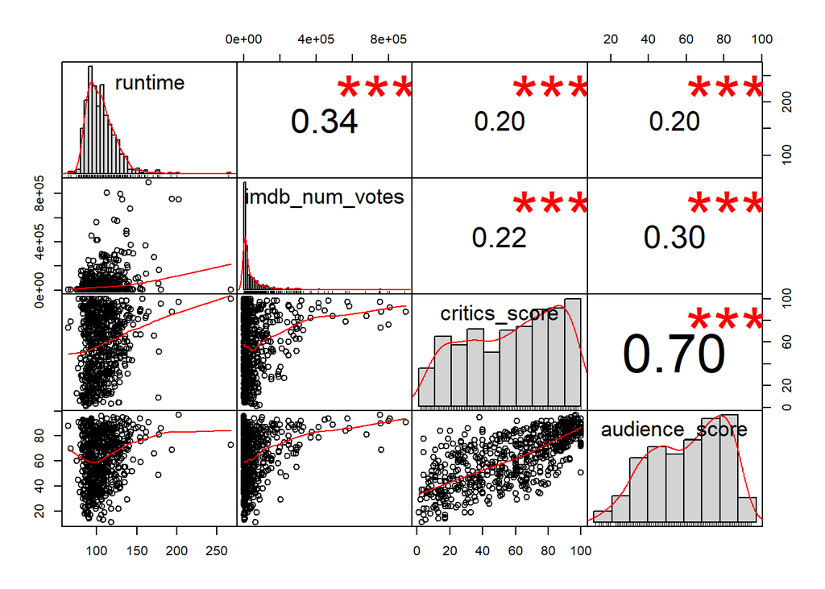

```r
chart.Correlation(movies3)
```

The audience_score have high correlation with critics store that can cause the inaccurancy in the modle due to colinearity.

#### 2) Linearity Condition: residuals should randomly scattered

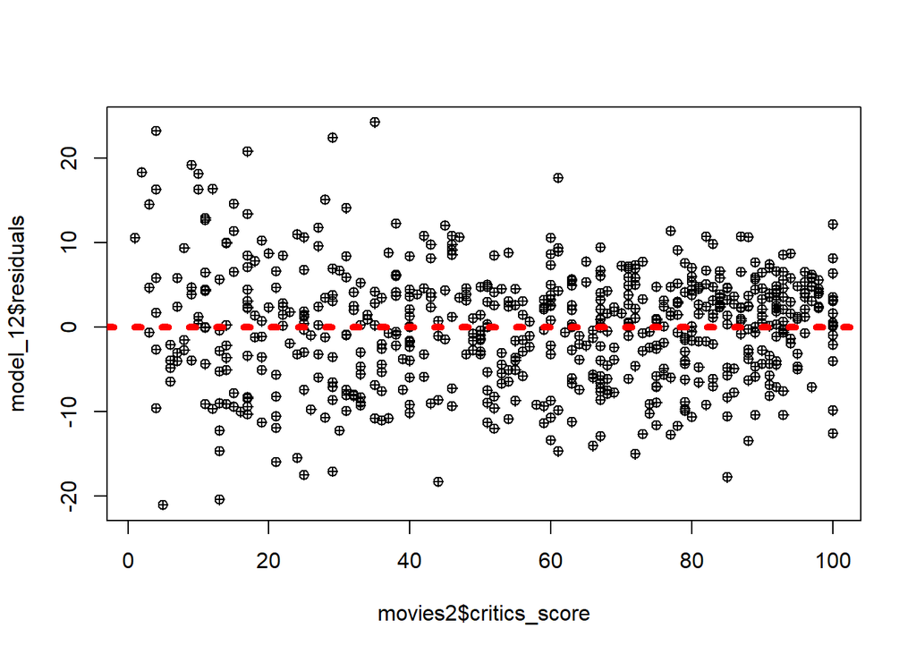

```r
plot(model_12$residuals~movies2$critics_score,pch=10)
abline(h=0, col="red", lty="dotted",lwd = 5 )
```

I seems residuals are randomly scattered , therfore, these data met the assumption.

#### 3) Check for variability

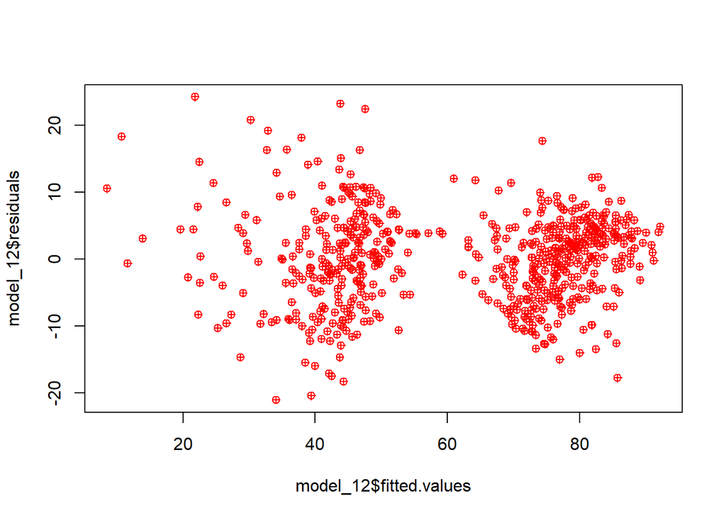

```r
plot(model_12$residuals~model_12$fitted.values, pch=10, col="red")
```

The assumption condition met because no fan pattern was observed.

#### 4) Independent assumption

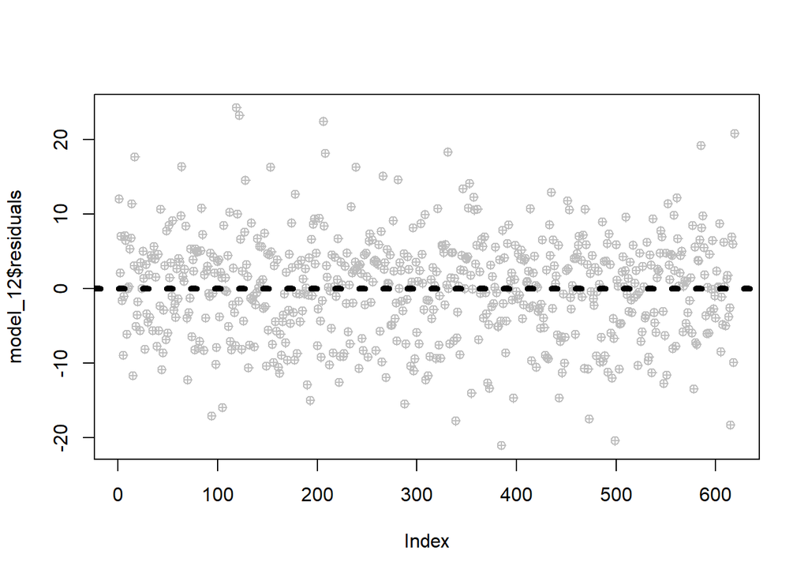

```r
plot(model_12$residuals,pch=10, col="gray" )
abline(h=0, lty="dotted",lwd = 5)
```

Residuals are randomly scatter around zero so, its met the assumptions.

## Part 5: Prediction

Now, based on our model, we want to predict the audience_score in movie “John Wick: Chapter 3 – Parabellum”. I extracted the data from the websites here snd create a new variable

```r
audience_score<-87
genre<-"Action & Adventure"
imdb_rating<-8
critics_score<-87
audience_rating<- "Upright"
```

Then, we are going to use our model to predict audience score in John Whick movie

```r
john_wick<-data.frame(audience_score,genre,imdb_rating,critics_score,audience_rating )
predict(model_12,john_wick)
```

```
##        1
## 86.08249
```

The actual audience_score for movie “John Wick: Chapter 3 – Parabellumis” was 87 and our model predicted audience score of 86.08249 that is very close to real score.

```r
predict(model_12,john_wick, interval="confidence")
```

```
##        fit     lwr      upr
## 1 86.08249 84.0101 88.15488
```

Based on the confidence interval prediction, We can mention that we are 95% confident that the actual audience_score for “John Wick: Chapter 3 – Parabellumis” movie 2019 is between 84.0101 and 88.15488. The model show that the actual value is in this confidence interval

## Part 6: Conclusion

My model works great, and I predicted audience_score for movie “John Wick: Chapter 3 – Parabellumis” correctly and really close to real value. I think the model will be more accurate if we add more variables such as “the time of day that movie is on theater”, “Grosses”, “Nationality of movie” and location of filming.